# Análise de Séries Temporais no Mercado Financeiro

Guilherme Matheus

13/01/2020

*Referencia: http://www.quantmod.com*

**Instalar e carregar os pacotes necessários:**

```r
install.packages("quantmod")
install.packages("xts")
install.packages("moments")
```

```r
library(quantmod)
library(xts)
library(moments)
```

**Seleção do período de análise**

```r
startDate = as.Date("2019-01-01")
endDate = as.Date("2019-12-31")
```

**Download dos dados do período**

*Obs.: O Yahoo Finance está passando por mudanças e o serviço de cotações online pode estar instável, portanto, caso apresente erro na função abaixo, favor executar a segunda função.*

1ª:

```r
getSymbols("PETR4.SA", src = "yahoo", from = startDate, to = endDate, auto.assign = T)
```

```
## [1] "PETR4.SA"
```

2ª:

```r
PETR4.SA = readRDS("PETR4.SA.rds")
```

**Checando o tipo de dado retornado**

```r
class(PETR4.SA)
```

```
## [1] "xts" "zoo"
```

```r
is.xts(PETR4.SA)
```

```
## [1] TRUE
```

**Mostra os primeiros registros para as ações da Petrobras**

```r
head(PETR4.SA)
```

```
##            PETR4.SA.Open PETR4.SA.High PETR4.SA.Low PETR4.SA.Close
## 2019-01-02         22.55         24.20        22.28          24.06
## 2019-01-03         23.96         24.82        23.80          24.65
## 2019-01-04         24.85         24.94        24.47          24.72
## 2019-01-07         24.85         25.92        24.70          25.11
## 2019-01-08         25.40         25.42        24.77          24.96
## 2019-01-09         25.30         25.50        25.15          25.48
##            PETR4.SA.Volume PETR4.SA.Adjusted
## 2019-01-02       104534800          23.28871
## 2019-01-03        95206400          23.85979
## 2019-01-04        72119800          23.92755
## 2019-01-07       121711900          24.30505
## 2019-01-08        68761800          24.15985
## 2019-01-09        70177600          24.66318
```

```r
View(PETR4.SA)
```

**Analisando os dados de fechamento**

```r
PETR4.SA.Close <- PETR4.SA[, "PETR4.SA.Close"]
is.xts(PETR4.SA.Close)
```

```
## [1] TRUE
```

```r
head(Cl(PETR4.SA),5)
```

```
##            PETR4.SA.Close
## 2019-01-02          24.06
## 2019-01-03          24.65
## 2019-01-04          24.72
## 2019-01-07          25.11
## 2019-01-08          24.96
```

**Agora, vamos plotar o gráfico da Petrobras**

**Gráfico de candlestick da Petrobras**

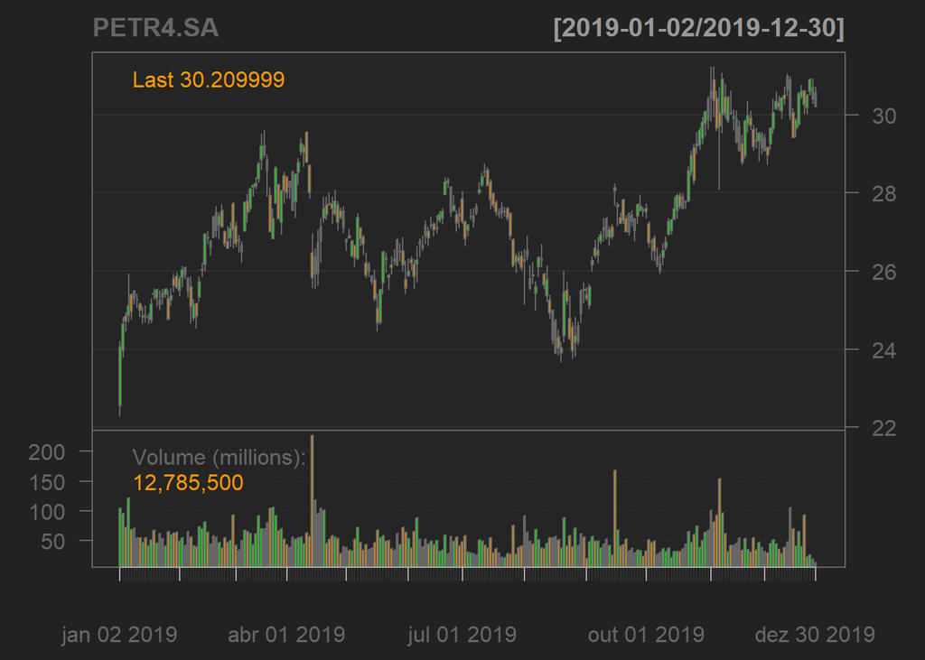

```r
candleChart(PETR4.SA)
```

**Plot do fechamento**

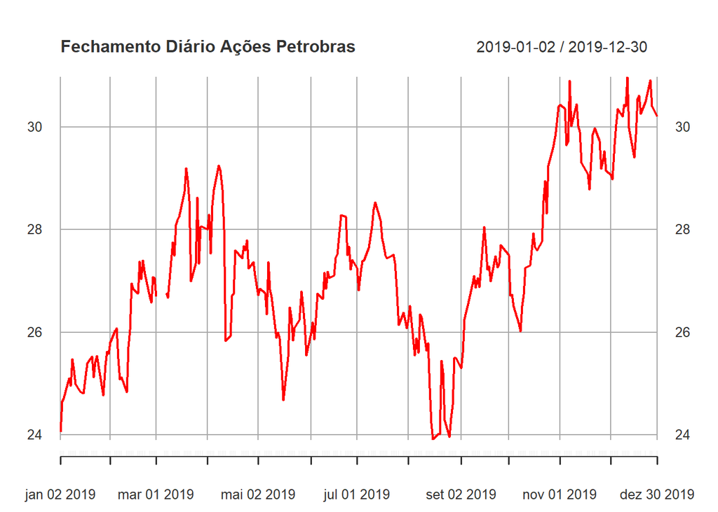

```r
plot(PETR4.SA.Close, main = "Fechamento Diário Ações Petrobras",
     col = "red", xlab = "Data", ylab = "Preço", major.ticks = 'months',
     minor.ticks = FALSE)
```

**Adicionado as bandas de bollinger ao gráfico, com média de 20 períodos e 2 desvios** *Bollinger Band* Como o desvio padrão é uma medida de volatilidade, Bollinger Bands ajustam-se às condições de mercado. Mercados mais voláteis, possuem as bandas mais distantes da média, enquanto mercados menso voláteis possuem as bancas mais próximas da média.

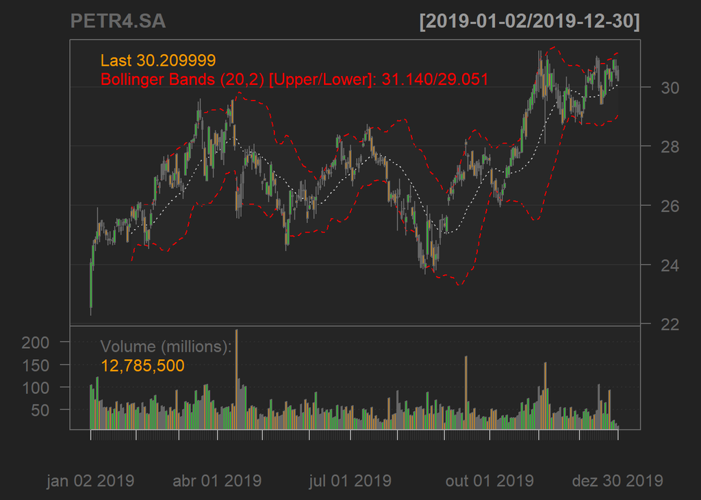

```r
addBBands(n = 20, sd = 2)
```

**Adicionando o indicador ADX, média 11 do tipo exponencial**

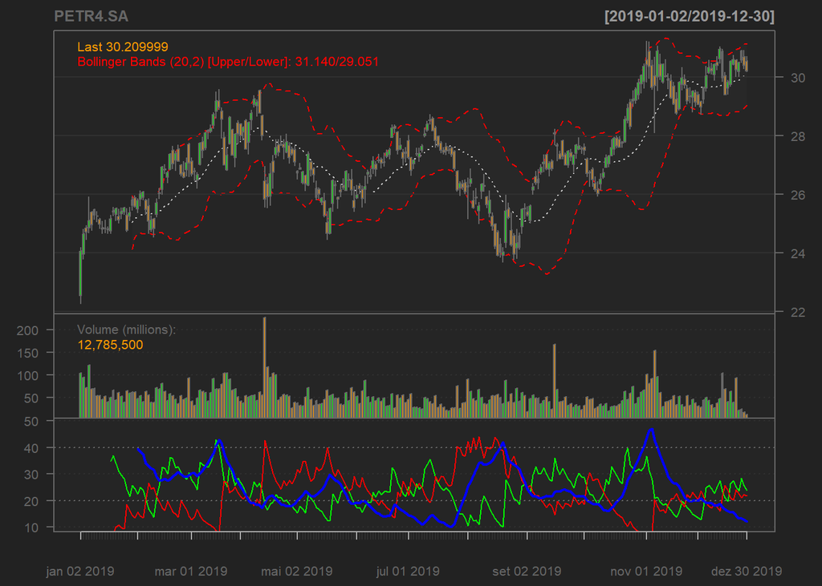

```r
addADX(n = 11, maType = "EMA")
```

**Calculando logs diários**

```r
PETR4.SA.ret <- diff(log(PETR4.SA.Close), lag = 1)
```

**Remove valores NA na prosição 1**

```r
PETR4.SA.ret <- PETR4.SA.ret[-1]
```

**Plotar a taxa de retornO**

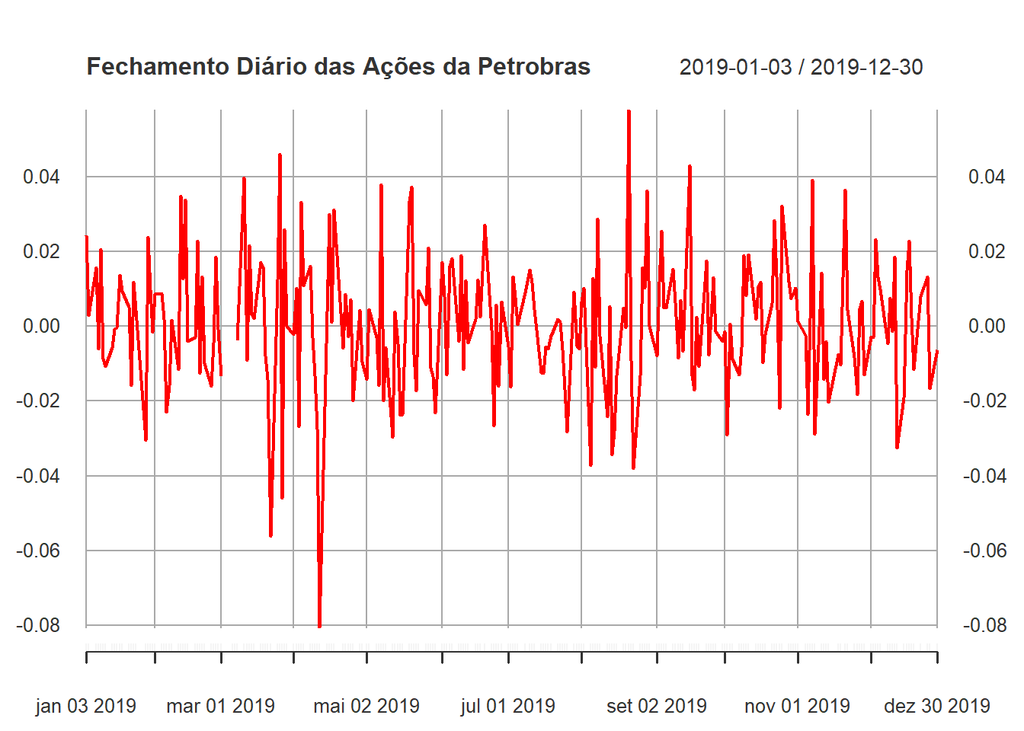

```r
plot(PETR4.SA.ret, main = "Fechamento Diário das Ações da Petrobras",
     col = "red", xlab = "Data", ylab = "Retorno", major.ticks = 'months',
     minor.ticks = FALSE)
```

**Calculando algumas medidas estatísticas**

```r
statNames <- c("Mean", "Standard Deviation", "Skewness", "Kurtosis")
PETR4.SA.stats <- c(mean(PETR4.SA.ret), sd(PETR4.SA.ret), skewness(PETR4.SA.ret), kurtosis(PETR4.SA.ret))
names(PETR4.SA.stats) <- statNames
PETR4.SA.stats
```

```
##               Mean Standard Deviation           Skewness           Kurtosis
##                 NA                 NA                 NA                 NA
```

**Salvando os dados em um arquivo .rds (arquivo em formato binário do R)**

```r
# getSymbols("PETR4.SA", src = 'yahoo')

saveRDS(PETR4.SA, file = "PETR4.SA.rds") # Salva os dados em formato binário
Ptr = readRDS("PETR4.SA.rds")
```

```r
head(Ptr)
```

```
##            PETR4.SA.Open PETR4.SA.High PETR4.SA.Low PETR4.SA.Close
## 2019-01-02         22.55         24.20        22.28          24.06
## 2019-01-03         23.96         24.82        23.80          24.65
## 2019-01-04         24.85         24.94        24.47          24.72
## 2019-01-07         24.85         25.92        24.70          25.11
## 2019-01-08         25.40         25.42        24.77          24.96
## 2019-01-09         25.30         25.50        25.15          25.48
##            PETR4.SA.Volume PETR4.SA.Adjusted
## 2019-01-02       104534800          23.28871
## 2019-01-03        95206400          23.85979
## 2019-01-04        72119800          23.92755
## 2019-01-07       121711900          24.30505
## 2019-01-08        68761800          24.15985
## 2019-01-09        70177600          24.66318
```